# Risk Factor Analysis

## Outcome Variable

**Outcome Variable:** haz

## Predictor Variables

**Intervention Variable:** enstunt

**Adjustment Set:**

- arm
- sex
- W_mage
- meducyrs
- feducyrs
- vagbrth
- single
- brthmon
- W_parity
- delta_W_mage
- delta_meducyrs
- delta_feducyrs
- delta_vagbrth
- delta_single
- delta_brthmon
- delta_W_parity

## Stratifying Variables

The analysis was stratified on these variable(s):

- agecat
- studyid
- country

## Data Summary

| agecat | studyid | country | enstunt | n_cell | n |
| --- | --- | --- | --- | --- | --- |
| Birth | ki0047075b-MAL-ED | BANGLADESH | 0 | 210 | 257 |
| Birth | ki0047075b-MAL-ED | BANGLADESH | 1 | 47 | 257 |
| Birth | ki0047075b-MAL-ED | BRAZIL | 0 | 170 | 191 |
| Birth | ki0047075b-MAL-ED | BRAZIL | 1 | 21 | 191 |
| Birth | ki0047075b-MAL-ED | INDIA | 0 | 173 | 206 |
| Birth | ki0047075b-MAL-ED | INDIA | 1 | 33 | 206 |
| Birth | ki0047075b-MAL-ED | NEPAL | 0 | 155 | 173 |
| Birth | ki0047075b-MAL-ED | NEPAL | 1 | 18 | 173 |
| Birth | ki0047075b-MAL-ED | PERU | 0 | 253 | 287 |
| Birth | ki0047075b-MAL-ED | PERU | 1 | 34 | 287 |
| Birth | ki0047075b-MAL-ED | SOUTH AFRICA | 0 | 234 | 262 |
| Birth | ki0047075b-MAL-ED | SOUTH AFRICA | 1 | 28 | 262 |
| Birth | ki0047075b-MAL-ED | TANZANIA, UNITED REPUBLIC OF | 0 | 105 | 123 |
| Birth | ki0047075b-MAL-ED | TANZANIA, UNITED REPUBLIC OF | 1 | 18 | 123 |
| Birth | ki1000108-CMC-V-BCS-2002 | INDIA | 0 | 74 | 90 |
| Birth | ki1000108-CMC-V-BCS-2002 | INDIA | 1 | 16 | 90 |
| Birth | ki1000108-IRC | INDIA | 0 | 343 | 388 |
| Birth | ki1000108-IRC | INDIA | 1 | 45 | 388 |
| Birth | ki1000109-EE | PAKISTAN | 0 | 1 | 2 |
| Birth | ki1000109-EE | PAKISTAN | 1 | 1 | 2 |
| Birth | ki1000109-ResPak | PAKISTAN | 0 | 5 | 7 |
| Birth | ki1000109-ResPak | PAKISTAN | 1 | 2 | 7 |
| Birth | ki1000304b-SAS-CompFeed | INDIA | 0 | 141 | 187 |
| Birth | ki1000304b-SAS-CompFeed | INDIA | 1 | 46 | 187 |
| Birth | ki1017093-NIH-Birth | BANGLADESH | 0 | 27 | 28 |
| Birth | ki1017093-NIH-Birth | BANGLADESH | 1 | 1 | 28 |
| Birth | ki1017093c-NIH-Crypto | BANGLADESH | 0 | 22 | 27 |
| Birth | ki1017093c-NIH-Crypto | BANGLADESH | 1 | 5 | 27 |
| Birth | ki1101329-Keneba | GAMBIA | 0 | 1459 | 1541 |
| Birth | ki1101329-Keneba | GAMBIA | 1 | 82 | 1541 |

[output cut: 142 more lines]

The following strata were considered:

- agecat: 24 months, studyid: ki0047075b-MAL-ED, country: BANGLADESH
- agecat: 24 months, studyid: ki0047075b-MAL-ED, country: BRAZIL
- agecat: 24 months, studyid: ki0047075b-MAL-ED, country: INDIA
- agecat: 24 months, studyid: ki0047075b-MAL-ED, country: NEPAL
- agecat: 24 months, studyid: ki0047075b-MAL-ED, country: PERU
- agecat: 24 months, studyid: ki0047075b-MAL-ED, country: SOUTH AFRICA
- agecat: 24 months, studyid: ki0047075b-MAL-ED, country: TANZANIA, UNITED REPUBLIC OF
- agecat: 24 months, studyid: ki1000108-CMC-V-BCS-2002, country: INDIA
- agecat: 24 months, studyid: ki1000108-IRC, country: INDIA
- agecat: 24 months, studyid: ki1017093-NIH-Birth, country: BANGLADESH
- agecat: 24 months, studyid: ki1017093b-PROVIDE, country: BANGLADESH
- agecat: 24 months, studyid: ki1017093c-NIH-Crypto, country: BANGLADESH
- agecat: 24 months, studyid: ki1066203-TanzaniaChild2, country: TANZANIA, UNITED REPUBLIC OF
- agecat: 24 months, studyid: ki1101329-Keneba, country: GAMBIA
- agecat: 24 months, studyid: ki1113344-GMS-Nepal, country: NEPAL
- agecat: 24 months, studyid: ki1114097-CMIN, country: BANGLADESH
- agecat: 24 months, studyid: ki1114097-CMIN, country: GUINEA-BISSAU
- agecat: 24 months, studyid: ki1114097-CMIN, country: PERU
- agecat: 24 months, studyid: ki1114097-CONTENT, country: PERU
- agecat: 24 months, studyid: ki1119695-PROBIT, country: BELARUS
- agecat: 24 months, studyid: ki1126311-ZVITAMBO, country: ZIMBABWE
- agecat: 24 months, studyid: ki1135781-COHORTS, country: GUATEMALA
- agecat: 24 months, studyid: ki1135781-COHORTS, country: INDIA
- agecat: 24 months, studyid: ki1135781-COHORTS, country: PHILIPPINES
- agecat: 24 months, studyid: ki1148112-LCNI-5, country: MALAWI
- agecat: 24 months, studyid: kiGH5241-JiVitA-3, country: BANGLADESH
- agecat: 24 months, studyid: kiGH5241-JiVitA-4, country: BANGLADESH
- agecat: 6 months, studyid: ki0047075b-MAL-ED, country: BANGLADESH
- agecat: 6 months, studyid: ki0047075b-MAL-ED, country: BRAZIL
- agecat: 6 months, studyid: ki0047075b-MAL-ED, country: INDIA
- agecat: 6 months, studyid: ki0047075b-MAL-ED, country: NEPAL
- agecat: 6 months, studyid: ki0047075b-MAL-ED, country: PERU
- agecat: 6 months, studyid: ki0047075b-MAL-ED, country: SOUTH AFRICA
- agecat: 6 months, studyid: ki0047075b-MAL-ED, country: TANZANIA, UNITED REPUBLIC OF
- agecat: 6 months, studyid: ki1000108-CMC-V-BCS-2002, country: INDIA
- agecat: 6 months, studyid: ki1000108-IRC, country: INDIA
- agecat: 6 months, studyid: ki1000109-EE, country: PAKISTAN
- agecat: 6 months, studyid: ki1000109-ResPak, country: PAKISTAN
- agecat: 6 months, studyid: ki1000304b-SAS-CompFeed, country: INDIA
- agecat: 6 months, studyid: ki1000304b-SAS-FoodSuppl, country: INDIA
- agecat: 6 months, studyid: ki1017093-NIH-Birth, country: BANGLADESH
- agecat: 6 months, studyid: ki1017093b-PROVIDE, country: BANGLADESH
- agecat: 6 months, studyid: ki1017093c-NIH-Crypto, country: BANGLADESH
- agecat: 6 months, studyid: ki1066203-TanzaniaChild2, country: TANZANIA, UNITED REPUBLIC OF
- agecat: 6 months, studyid: ki1101329-Keneba, country: GAMBIA
- agecat: 6 months, studyid: ki1112895-Guatemala BSC, country: GUATEMALA
- agecat: 6 months, studyid: ki1113344-GMS-Nepal, country: NEPAL
- agecat: 6 months, studyid: ki1114097-CMIN, country: BANGLADESH
- agecat: 6 months, studyid: ki1114097-CMIN, country: BRAZIL
- agecat: 6 months, studyid: ki1114097-CMIN, country: GUINEA-BISSAU
- agecat: 6 months, studyid: ki1114097-CMIN, country: PERU
- agecat: 6 months, studyid: ki1114097-CONTENT, country: PERU
- agecat: 6 months, studyid: ki1119695-PROBIT, country: BELARUS
- agecat: 6 months, studyid: ki1126311-ZVITAMBO, country: ZIMBABWE
- agecat: 6 months, studyid: ki1135781-COHORTS, country: GUATEMALA
- agecat: 6 months, studyid: ki1135781-COHORTS, country: INDIA
- agecat: 6 months, studyid: ki1135781-COHORTS, country: PHILIPPINES
- agecat: 6 months, studyid: ki1148112-LCNI-5, country: MALAWI
- agecat: 6 months, studyid: kiGH5241-JiVitA-3, country: BANGLADESH
- agecat: 6 months, studyid: kiGH5241-JiVitA-4, country: BANGLADESH
- agecat: Birth, studyid: ki0047075b-MAL-ED, country: BANGLADESH
- agecat: Birth, studyid: ki0047075b-MAL-ED, country: BRAZIL
- agecat: Birth, studyid: ki0047075b-MAL-ED, country: INDIA
- agecat: Birth, studyid: ki0047075b-MAL-ED, country: NEPAL
- agecat: Birth, studyid: ki0047075b-MAL-ED, country: PERU
- agecat: Birth, studyid: ki0047075b-MAL-ED, country: SOUTH AFRICA
- agecat: Birth, studyid: ki0047075b-MAL-ED, country: TANZANIA, UNITED REPUBLIC OF
- agecat: Birth, studyid: ki1000108-CMC-V-BCS-2002, country: INDIA
- agecat: Birth, studyid: ki1000108-IRC, country: INDIA
- agecat: Birth, studyid: ki1000109-EE, country: PAKISTAN
- agecat: Birth, studyid: ki1000109-ResPak, country: PAKISTAN
- agecat: Birth, studyid: ki1000304b-SAS-CompFeed, country: INDIA
- agecat: Birth, studyid: ki1017093-NIH-Birth, country: BANGLADESH
- agecat: Birth, studyid: ki1017093c-NIH-Crypto, country: BANGLADESH
- agecat: Birth, studyid: ki1101329-Keneba, country: GAMBIA
- agecat: Birth, studyid: ki1114097-CMIN, country: BANGLADESH
- agecat: Birth, studyid: ki1114097-CMIN, country: BRAZIL
- agecat: Birth, studyid: ki1114097-CMIN, country: PERU
- agecat: Birth, studyid: ki1114097-CONTENT, country: PERU
- agecat: Birth, studyid: ki1119695-PROBIT, country: BELARUS
- agecat: Birth, studyid: ki1126311-ZVITAMBO, country: ZIMBABWE
- agecat: Birth, studyid: ki1135781-COHORTS, country: GUATEMALA
- agecat: Birth, studyid: ki1135781-COHORTS, country: INDIA
- agecat: Birth, studyid: ki1135781-COHORTS, country: PHILIPPINES
- agecat: Birth, studyid: kiGH5241-JiVitA-3, country: BANGLADESH
- agecat: Birth, studyid: kiGH5241-JiVitA-4, country: BANGLADESH

### Dropped Strata

Some strata were dropped due to rare outcomes:

- agecat: Birth, studyid: ki1000109-EE, country: PAKISTAN
- agecat: Birth, studyid: ki1000109-ResPak, country: PAKISTAN
- agecat: Birth, studyid: ki1017093-NIH-Birth, country: BANGLADESH
- agecat: Birth, studyid: ki1114097-CMIN, country: PERU
- agecat: Birth, studyid: ki1114097-CONTENT, country: PERU
- agecat: 6 months, studyid: ki1114097-CMIN, country: BRAZIL
- agecat: 24 months, studyid: ki1066203-TanzaniaChild2, country: TANZANIA, UNITED REPUBLIC OF

## Methods Detail

We’re interested in the causal parameters $E[Y_a]$ for all values of $a \in \mathcal{A}$. These parameters represent the mean outcome if, possibly contrary to fact, we intervened to set all units to have $A=a$. Under the randomization and positivity assumptions, these are identified by the statistical parameters $\psi_a=E_W[E_{Y|A,W}(Y|A=a,W)]$. In addition, we’re interested in the mean of $Y$, $E[Y]$ under no intervention (the observed mean). We will estimate these parameters by using SuperLearner to fit the relevant likelihood factors – $E_{Y|A,W}(Y|A=a,W)$ and $p(A=a|W)$, and then updating our likelihood fit using a joint TMLE.

For unadjusted analyses ($W=\{\}$), initial likelihoods were estimated using Lrnr_glm to estimate the simple $E(Y|A)$ and Lrnr_mean to estimate $p(A)$. For adjusted analyses, a small library containing Lrnr_glmnet, Lrnr_xgboost, and Lrnr_mean was used.

Having estimated these parameters, we will then use the delta method to estimate relative risks and attributable risks relative to a prespecified baseline level of $A$.

# Results Detail

## Results Plots

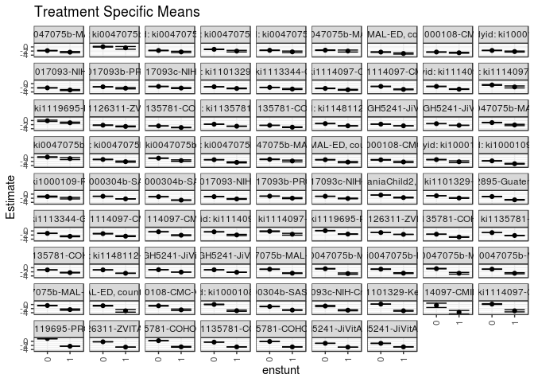

[figure not shown]

[figure not shown]

## Results Table

### Parameter: TSM

| agecat | studyid | country | intervention_level | baseline_level | estimate | ci_lower | ci_upper |
| --- | --- | --- | --- | --- | --- | --- | --- |
| Birth | ki0047075b-MAL-ED | BANGLADESH | 0 | NA | -0.7343945 | -0.8347848 | -0.6340042 |
| Birth | ki0047075b-MAL-ED | BANGLADESH | 1 | NA | -2.6645622 | -2.8276326 | -2.5014918 |
| Birth | ki0047075b-MAL-ED | BRAZIL | 0 | NA | -0.5041366 | -0.6304595 | -0.3778137 |
| Birth | ki0047075b-MAL-ED | BRAZIL | 1 | NA | -2.8581102 | -3.1740865 | -2.5421339 |
| Birth | ki0047075b-MAL-ED | INDIA | 0 | NA | -0.6942324 | -0.8049765 | -0.5834884 |
| Birth | ki0047075b-MAL-ED | INDIA | 1 | NA | -2.6564341 | -2.8581124 | -2.4547557 |
| Birth | ki0047075b-MAL-ED | NEPAL | 0 | NA | -0.4629109 | -0.5868709 | -0.3389509 |
| Birth | ki0047075b-MAL-ED | NEPAL | 1 | NA | -2.6938909 | -3.1076595 | -2.2801224 |
| Birth | ki0047075b-MAL-ED | PERU | 0 | NA | -0.6945707 | -0.7864745 | -0.6026669 |
| Birth | ki0047075b-MAL-ED | PERU | 1 | NA | -2.6958907 | -2.9666618 | -2.4251196 |
| Birth | ki0047075b-MAL-ED | SOUTH AFRICA | 0 | NA | -0.5008732 | -0.6088474 | -0.3928990 |
| Birth | ki0047075b-MAL-ED | SOUTH AFRICA | 1 | NA | -2.4865512 | -2.7950930 | -2.1780094 |
| Birth | ki0047075b-MAL-ED | TANZANIA, UNITED REPUBLIC OF | 0 | NA | -0.5844066 | -0.7402574 | -0.4285559 |
| Birth | ki0047075b-MAL-ED | TANZANIA, UNITED REPUBLIC OF | 1 | NA | -3.0559316 | -3.7070201 | -2.4048430 |
| Birth | ki1000108-CMC-V-BCS-2002 | INDIA | 0 | NA | -0.6186522 | -0.7727511 | -0.4645533 |
| Birth | ki1000108-CMC-V-BCS-2002 | INDIA | 1 | NA | -2.5990825 | -2.9708962 | -2.2272688 |
| Birth | ki1000108-IRC | INDIA | 0 | NA | 0.0492704 | -0.0890338 | 0.1875746 |
| Birth | ki1000108-IRC | INDIA | 1 | NA | -2.9965045 | -3.3124392 | -2.6805699 |
| Birth | ki1000304b-SAS-CompFeed | INDIA | 0 | NA | -0.9615123 | -1.0672502 | -0.8557745 |
| Birth | ki1000304b-SAS-CompFeed | INDIA | 1 | NA | -2.7112430 | -2.8879901 | -2.5344959 |
| Birth | ki1017093c-NIH-Crypto | BANGLADESH | 0 | NA | -0.7318182 | -1.0404321 | -0.4232043 |
| Birth | ki1017093c-NIH-Crypto | BANGLADESH | 1 | NA | -2.7740000 | -3.0567771 | -2.4912229 |
| Birth | ki1101329-Keneba | GAMBIA | 0 | NA | 0.2053721 | 0.1518887 | 0.2588555 |
| Birth | ki1101329-Keneba | GAMBIA | 1 | NA | -3.0370498 | -3.2779055 | -2.7961942 |
| Birth | ki1114097-CMIN | BANGLADESH | 0 | NA | -0.4085714 | -1.4766014 | 0.6594585 |
| Birth | ki1114097-CMIN | BANGLADESH | 1 | NA | -3.7300000 | -4.5650701 | -2.8949299 |
| Birth | ki1114097-CMIN | BRAZIL | 0 | NA | 0.1989091 | 0.0282832 | 0.3695350 |
| Birth | ki1114097-CMIN | BRAZIL | 1 | NA | -3.0500000 | -3.5786844 | -2.5213156 |
| Birth | ki1119695-PROBIT | BELARUS | 0 | NA | 1.3340838 | 1.1734159 | 1.4947518 |
| Birth | ki1119695-PROBIT | BELARUS | 1 | NA | -2.3889555 | -2.4119083 | -2.3660027 |

[output cut: 128 more lines]

### Parameter: E(Y)

| agecat | studyid | country | intervention_level | baseline_level | estimate | ci_lower | ci_upper |
| --- | --- | --- | --- | --- | --- | --- | --- |
| Birth | ki0047075b-MAL-ED | BANGLADESH | NA | NA | -1.0843969 | -1.2100768 | -0.9587169 |
| Birth | ki0047075b-MAL-ED | BRAZIL | NA | NA | -0.7609424 | -0.9178311 | -0.6040538 |
| Birth | ki0047075b-MAL-ED | INDIA | NA | NA | -1.0106311 | -1.1499962 | -0.8712660 |
| Birth | ki0047075b-MAL-ED | NEPAL | NA | NA | -0.7089017 | -0.8656064 | -0.5521971 |
| Birth | ki0047075b-MAL-ED | PERU | NA | NA | -0.9322300 | -1.0461262 | -0.8183337 |
| Birth | ki0047075b-MAL-ED | SOUTH AFRICA | NA | NA | -0.7266031 | -0.8549719 | -0.5982342 |
| Birth | ki0047075b-MAL-ED | TANZANIA, UNITED REPUBLIC OF | NA | NA | -0.9338211 | -1.1465079 | -0.7211344 |
| Birth | ki1000108-CMC-V-BCS-2002 | INDIA | NA | NA | -0.9654444 | -1.1742112 | -0.7566777 |
| Birth | ki1000108-IRC | INDIA | NA | NA | -0.3080412 | -0.4687931 | -0.1472894 |
| Birth | ki1000304b-SAS-CompFeed | INDIA | NA | NA | -1.3946524 | -1.5833612 | -1.2059436 |
| Birth | ki1017093c-NIH-Crypto | BANGLADESH | NA | NA | -1.1100000 | -1.5086894 | -0.7113106 |
| Birth | ki1101329-Keneba | GAMBIA | NA | NA | 0.0341467 | -0.0293905 | 0.0976838 |
| Birth | ki1114097-CMIN | BANGLADESH | NA | NA | -1.9415385 | -3.1064163 | -0.7766606 |
| Birth | ki1114097-CMIN | BRAZIL | NA | NA | 0.0576522 | -0.1471825 | 0.2624869 |
| Birth | ki1119695-PROBIT | BELARUS | NA | NA | 1.3254775 | 1.1669293 | 1.4840258 |
| Birth | ki1126311-ZVITAMBO | ZIMBABWE | NA | NA | -0.5009660 | -0.5215391 | -0.4803930 |
| Birth | ki1135781-COHORTS | GUATEMALA | NA | NA | 0.1297300 | 0.0458017 | 0.2136584 |
| Birth | ki1135781-COHORTS | INDIA | NA | NA | -0.6698961 | -0.6980556 | -0.6417365 |
| Birth | ki1135781-COHORTS | PHILIPPINES | NA | NA | -0.2490492 | -0.2880580 | -0.2100404 |
| Birth | kiGH5241-JiVitA-3 | BANGLADESH | NA | NA | -1.5747407 | -1.5944667 | -1.5550147 |
| Birth | kiGH5241-JiVitA-4 | BANGLADESH | NA | NA | -1.4976642 | -1.5817349 | -1.4135935 |
| 6 months | ki0047075b-MAL-ED | BANGLADESH | NA | NA | -1.2056777 | -1.3231497 | -1.0882058 |
| 6 months | ki0047075b-MAL-ED | BRAZIL | NA | NA | 0.0510207 | -0.0930194 | 0.1950608 |
| 6 months | ki0047075b-MAL-ED | INDIA | NA | NA | -1.2203672 | -1.3387619 | -1.1019726 |
| 6 months | ki0047075b-MAL-ED | NEPAL | NA | NA | -0.5610593 | -0.6737915 | -0.4483272 |
| 6 months | ki0047075b-MAL-ED | PERU | NA | NA | -1.3268010 | -1.4351217 | -1.2184802 |
| 6 months | ki0047075b-MAL-ED | SOUTH AFRICA | NA | NA | -1.0633760 | -1.1911088 | -0.9356432 |
| 6 months | ki0047075b-MAL-ED | TANZANIA, UNITED REPUBLIC OF | NA | NA | -1.3601215 | -1.4821830 | -1.2380600 |
| 6 months | ki1000108-CMC-V-BCS-2002 | INDIA | NA | NA | -1.4234508 | -1.5645974 | -1.2823042 |
| 6 months | ki1000108-IRC | INDIA | NA | NA | -1.2344062 | -1.3658524 | -1.1029600 |
| 6 months | ki1000109-EE | PAKISTAN | NA | NA | -2.2004704 | -2.3234073 | -2.0775336 |
| 6 months | ki1000109-ResPak | PAKISTAN | NA | NA | -1.4029220 | -1.6085859 | -1.1972581 |
| 6 months | ki1000304b-SAS-CompFeed | INDIA | NA | NA | -1.4018563 | -1.4810585 | -1.3226541 |
| 6 months | ki1000304b-SAS-FoodSuppl | INDIA | NA | NA | -1.8986842 | -2.0118892 | -1.7854792 |
| 6 months | ki1017093-NIH-Birth | BANGLADESH | NA | NA | -1.4073821 | -1.4960598 | -1.3187043 |
| 6 months | ki1017093b-PROVIDE | BANGLADESH | NA | NA | -1.0871041 | -1.1635539 | -1.0106543 |
| 6 months | ki1017093c-NIH-Crypto | BANGLADESH | NA | NA | -1.1986783 | -1.2700937 | -1.1272630 |
| 6 months | ki1066203-TanzaniaChild2 | TANZANIA, UNITED REPUBLIC OF | NA | NA | -0.5434389 | -0.5924056 | -0.4944722 |
| 6 months | ki1101329-Keneba | GAMBIA | NA | NA | -0.9041369 | -0.9513363 | -0.8569376 |
| 6 months | ki1112895-Guatemala BSC | GUATEMALA | NA | NA | -1.5619008 | -1.6727702 | -1.4510313 |
| 6 months | ki1113344-GMS-Nepal | NEPAL | NA | NA | -1.3321522 | -1.4103691 | -1.2539352 |
| 6 months | ki1114097-CMIN | BANGLADESH | NA | NA | -1.7844376 | -1.9222926 | -1.6465825 |
| 6 months | ki1114097-CMIN | GUINEA-BISSAU | NA | NA | -0.6075943 | -0.6832781 | -0.5319106 |
| 6 months | ki1114097-CMIN | PERU | NA | NA | -0.5132548 | -0.5926717 | -0.4338380 |
| 6 months | ki1114097-CONTENT | PERU | NA | NA | -0.3139217 | -0.4868486 | -0.1409948 |
| 6 months | ki1119695-PROBIT | BELARUS | NA | NA | 0.1069986 | 0.0122286 | 0.2017686 |
| 6 months | ki1126311-ZVITAMBO | ZIMBABWE | NA | NA | -0.8907480 | -0.9167182 | -0.8647779 |
| 6 months | ki1135781-COHORTS | GUATEMALA | NA | NA | -1.8157336 | -1.8837688 | -1.7476985 |
| 6 months | ki1135781-COHORTS | INDIA | NA | NA | -0.9968455 | -1.0246180 | -0.9690730 |
| 6 months | ki1135781-COHORTS | PHILIPPINES | NA | NA | -1.1405724 | -1.1824954 | -1.0986493 |
| 6 months | ki1148112-LCNI-5 | MALAWI | NA | NA | -1.6601907 | -1.7297701 | -1.5906113 |
| 6 months | kiGH5241-JiVitA-3 | BANGLADESH | NA | NA | -1.3130932 | -1.3362359 | -1.2899505 |
| 6 months | kiGH5241-JiVitA-4 | BANGLADESH | NA | NA | -1.3447940 | -1.3820261 | -1.3075620 |
| 24 months | ki0047075b-MAL-ED | BANGLADESH | NA | NA | -1.9431132 | -2.0691678 | -1.8170586 |
| 24 months | ki0047075b-MAL-ED | BRAZIL | NA | NA | 0.0418343 | -0.1253834 | 0.2090521 |
| 24 months | ki0047075b-MAL-ED | INDIA | NA | NA | -1.8458150 | -1.9718703 | -1.7197596 |
| 24 months | ki0047075b-MAL-ED | NEPAL | NA | NA | -1.2752193 | -1.3954783 | -1.1549603 |
| 24 months | ki0047075b-MAL-ED | PERU | NA | NA | -1.7500995 | -1.8705474 | -1.6296516 |
| 24 months | ki0047075b-MAL-ED | SOUTH AFRICA | NA | NA | -1.6228361 | -1.7581177 | -1.4875546 |
| 24 months | ki0047075b-MAL-ED | TANZANIA, UNITED REPUBLIC OF | NA | NA | -2.6058879 | -2.7403043 | -2.4714714 |
| 24 months | ki1000108-CMC-V-BCS-2002 | INDIA | NA | NA | -2.5593683 | -2.6601027 | -2.4586339 |
| 24 months | ki1000108-IRC | INDIA | NA | NA | -1.7824776 | -1.8765600 | -1.6883952 |
| 24 months | ki1017093-NIH-Birth | BANGLADESH | NA | NA | -2.1807945 | -2.2835902 | -2.0779987 |
| 24 months | ki1017093b-PROVIDE | BANGLADESH | NA | NA | -1.5861179 | -1.6693668 | -1.5028689 |
| 24 months | ki1017093c-NIH-Crypto | BANGLADESH | NA | NA | -1.4295331 | -1.5127726 | -1.3462935 |
| 24 months | ki1101329-Keneba | GAMBIA | NA | NA | -1.5626652 | -1.6124881 | -1.5128424 |
| 24 months | ki1113344-GMS-Nepal | NEPAL | NA | NA | -1.8835905 | -1.9681499 | -1.7990312 |
| 24 months | ki1114097-CMIN | BANGLADESH | NA | NA | -2.5109504 | -2.6361514 | -2.3857494 |
| 24 months | ki1114097-CMIN | GUINEA-BISSAU | NA | NA | -1.5745644 | -1.6739586 | -1.4751703 |
| 24 months | ki1114097-CMIN | PERU | NA | NA | -1.5807226 | -1.6772768 | -1.4841684 |
| 24 months | ki1114097-CONTENT | PERU | NA | NA | -0.6962195 | -0.8674103 | -0.5250287 |
| 24 months | ki1119695-PROBIT | BELARUS | NA | NA | -0.1314048 | -0.4282725 | 0.1654630 |
| 24 months | ki1126311-ZVITAMBO | ZIMBABWE | NA | NA | -2.3994530 | -2.5144490 | -2.2844569 |
| 24 months | ki1135781-COHORTS | GUATEMALA | NA | NA | -2.8612302 | -2.9255771 | -2.7968833 |
| 24 months | ki1135781-COHORTS | INDIA | NA | NA | -1.9067566 | -1.9394274 | -1.8740857 |
| 24 months | ki1135781-COHORTS | PHILIPPINES | NA | NA | -2.3898650 | -2.4346888 | -2.3450412 |
| 24 months | ki1148112-LCNI-5 | MALAWI | NA | NA | -1.8754404 | -1.9564117 | -1.7944692 |
| 24 months | kiGH5241-JiVitA-3 | BANGLADESH | NA | NA | -2.0126460 | -2.0403823 | -1.9849097 |
| 24 months | kiGH5241-JiVitA-4 | BANGLADESH | NA | NA | -1.7582681 | -1.7937283 | -1.7228079 |

### Parameter: ATE

| agecat | studyid | country | intervention_level | baseline_level | estimate | ci_lower | ci_upper |
| --- | --- | --- | --- | --- | --- | --- | --- |
| Birth | ki0047075b-MAL-ED | BANGLADESH | 0 | 0 | 0.0000000 | 0.0000000 | 0.0000000 |
| Birth | ki0047075b-MAL-ED | BANGLADESH | 1 | 0 | -1.9301677 | -2.1220178 | -1.7383176 |
| Birth | ki0047075b-MAL-ED | BRAZIL | 0 | 0 | 0.0000000 | 0.0000000 | 0.0000000 |
| Birth | ki0047075b-MAL-ED | BRAZIL | 1 | 0 | -2.3539736 | -2.6947267 | -2.0132204 |
| Birth | ki0047075b-MAL-ED | INDIA | 0 | 0 | 0.0000000 | 0.0000000 | 0.0000000 |
| Birth | ki0047075b-MAL-ED | INDIA | 1 | 0 | -1.9622016 | -2.1933489 | -1.7310543 |
| Birth | ki0047075b-MAL-ED | NEPAL | 0 | 0 | 0.0000000 | 0.0000000 | 0.0000000 |
| Birth | ki0047075b-MAL-ED | NEPAL | 1 | 0 | -2.2309801 | -2.6631108 | -1.7988493 |
| Birth | ki0047075b-MAL-ED | PERU | 0 | 0 | 0.0000000 | 0.0000000 | 0.0000000 |
| Birth | ki0047075b-MAL-ED | PERU | 1 | 0 | -2.0013199 | -2.2876066 | -1.7150332 |
| Birth | ki0047075b-MAL-ED | SOUTH AFRICA | 0 | 0 | 0.0000000 | 0.0000000 | 0.0000000 |
| Birth | ki0047075b-MAL-ED | SOUTH AFRICA | 1 | 0 | -1.9856780 | -2.3134859 | -1.6578702 |
| Birth | ki0047075b-MAL-ED | TANZANIA, UNITED REPUBLIC OF | 0 | 0 | 0.0000000 | 0.0000000 | 0.0000000 |
| Birth | ki0047075b-MAL-ED | TANZANIA, UNITED REPUBLIC OF | 1 | 0 | -2.4715250 | -3.1416616 | -1.8013884 |
| Birth | ki1000108-CMC-V-BCS-2002 | INDIA | 0 | 0 | 0.0000000 | 0.0000000 | 0.0000000 |
| Birth | ki1000108-CMC-V-BCS-2002 | INDIA | 1 | 0 | -1.9804303 | -2.3854792 | -1.5753813 |
| Birth | ki1000108-IRC | INDIA | 0 | 0 | 0.0000000 | 0.0000000 | 0.0000000 |
| Birth | ki1000108-IRC | INDIA | 1 | 0 | -3.0457750 | -3.3907277 | -2.7008222 |
| Birth | ki1000304b-SAS-CompFeed | INDIA | 0 | 0 | 0.0000000 | 0.0000000 | 0.0000000 |
| Birth | ki1000304b-SAS-CompFeed | INDIA | 1 | 0 | -1.7497307 | -1.9780860 | -1.5213754 |
| Birth | ki1017093c-NIH-Crypto | BANGLADESH | 0 | 0 | 0.0000000 | 0.0000000 | 0.0000000 |
| Birth | ki1017093c-NIH-Crypto | BANGLADESH | 1 | 0 | -2.0421818 | -2.4607573 | -1.6236064 |
| Birth | ki1101329-Keneba | GAMBIA | 0 | 0 | 0.0000000 | 0.0000000 | 0.0000000 |
| Birth | ki1101329-Keneba | GAMBIA | 1 | 0 | -3.2424219 | -3.4892991 | -2.9955447 |
| Birth | ki1114097-CMIN | BANGLADESH | 0 | 0 | 0.0000000 | 0.0000000 | 0.0000000 |
| Birth | ki1114097-CMIN | BANGLADESH | 1 | 0 | -3.3214286 | -4.6771683 | -1.9656889 |
| Birth | ki1114097-CMIN | BRAZIL | 0 | 0 | 0.0000000 | 0.0000000 | 0.0000000 |
| Birth | ki1114097-CMIN | BRAZIL | 1 | 0 | -3.2489091 | -3.8044453 | -2.6933729 |
| Birth | ki1119695-PROBIT | BELARUS | 0 | 0 | 0.0000000 | 0.0000000 | 0.0000000 |
| Birth | ki1119695-PROBIT | BELARUS | 1 | 0 | -3.7230393 | -3.8922934 | -3.5537852 |

[output cut: 128 more lines]

### Parameter: PAR

| agecat | studyid | country | intervention_level | baseline_level | estimate | ci_lower | ci_upper |
| --- | --- | --- | --- | --- | --- | --- | --- |
| Birth | ki0047075b-MAL-ED | BANGLADESH | 0 | NA | -0.3500024 | -0.4469857 | -0.2530192 |
| Birth | ki0047075b-MAL-ED | BRAZIL | 0 | NA | -0.2568058 | -0.3672380 | -0.1463736 |
| Birth | ki0047075b-MAL-ED | INDIA | 0 | NA | -0.3163986 | -0.4220187 | -0.2107786 |
| Birth | ki0047075b-MAL-ED | NEPAL | 0 | NA | -0.2459909 | -0.3591002 | -0.1328815 |
| Birth | ki0047075b-MAL-ED | PERU | 0 | NA | -0.2376593 | -0.3190374 | -0.1562811 |
| Birth | ki0047075b-MAL-ED | SOUTH AFRICA | 0 | NA | -0.2257299 | -0.3115924 | -0.1398674 |
| Birth | ki0047075b-MAL-ED | TANZANIA, UNITED REPUBLIC OF | 0 | NA | -0.3494145 | -0.5204236 | -0.1784054 |
| Birth | ki1000108-CMC-V-BCS-2002 | INDIA | 0 | NA | -0.3467922 | -0.5161587 | -0.1774257 |
| Birth | ki1000108-IRC | INDIA | 0 | NA | -0.3573117 | -0.4632427 | -0.2513806 |
| Birth | ki1000304b-SAS-CompFeed | INDIA | 0 | NA | -0.4331401 | -0.6069527 | -0.2593275 |
| Birth | ki1017093c-NIH-Crypto | BANGLADESH | 0 | NA | -0.3781818 | -0.6928017 | -0.0635619 |
| Birth | ki1101329-Keneba | GAMBIA | 0 | NA | -0.1712254 | -0.2098632 | -0.1325876 |
| Birth | ki1114097-CMIN | BANGLADESH | 0 | NA | -1.5329670 | -2.6595527 | -0.4063814 |
| Birth | ki1114097-CMIN | BRAZIL | 0 | NA | -0.1412569 | -0.2652554 | -0.0172584 |
| Birth | ki1119695-PROBIT | BELARUS | 0 | NA | -0.0086063 | -0.0130864 | -0.0041262 |
| Birth | ki1126311-ZVITAMBO | ZIMBABWE | 0 | NA | -0.2657549 | -0.2795931 | -0.2519166 |
| Birth | ki1135781-COHORTS | GUATEMALA | 0 | NA | -0.1771033 | -0.2276346 | -0.1265720 |
| Birth | ki1135781-COHORTS | INDIA | 0 | NA | -0.2772125 | -0.2963985 | -0.2580265 |
| Birth | ki1135781-COHORTS | PHILIPPINES | 0 | NA | -0.1613492 | -0.1846961 | -0.1380024 |
| Birth | kiGH5241-JiVitA-3 | BANGLADESH | 0 | NA | -0.6065845 | -0.6228134 | -0.5903557 |
| Birth | kiGH5241-JiVitA-4 | BANGLADESH | 0 | NA | -0.5155617 | -0.5836307 | -0.4474927 |
| 6 months | ki0047075b-MAL-ED | BANGLADESH | 0 | NA | -0.1952700 | -0.2725743 | -0.1179658 |
| 6 months | ki0047075b-MAL-ED | BRAZIL | 0 | NA | -0.0710444 | -0.1286641 | -0.0134248 |
| 6 months | ki0047075b-MAL-ED | INDIA | 0 | NA | -0.1782555 | -0.2516837 | -0.1048273 |
| 6 months | ki0047075b-MAL-ED | NEPAL | 0 | NA | -0.1375621 | -0.2005189 | -0.0746053 |
| 6 months | ki0047075b-MAL-ED | PERU | 0 | NA | -0.1593521 | -0.2211159 | -0.0975883 |
| 6 months | ki0047075b-MAL-ED | SOUTH AFRICA | 0 | NA | -0.0791643 | -0.1345120 | -0.0238166 |
| 6 months | ki0047075b-MAL-ED | TANZANIA, UNITED REPUBLIC OF | 0 | NA | -0.1836925 | -0.2560437 | -0.1113414 |
| 6 months | ki1000108-CMC-V-BCS-2002 | INDIA | 0 | NA | -0.1979100 | -0.2797012 | -0.1161187 |
| 6 months | ki1000108-IRC | INDIA | 0 | NA | -0.1141920 | -0.1724563 | -0.0559277 |
| 6 months | ki1000109-EE | PAKISTAN | 0 | NA | -0.4773881 | -0.5792672 | -0.3755089 |
| 6 months | ki1000109-ResPak | PAKISTAN | 0 | NA | -0.2064024 | -0.3292964 | -0.0835084 |
| 6 months | ki1000304b-SAS-CompFeed | INDIA | 0 | NA | -0.3452698 | -0.3867050 | -0.3038345 |
| 6 months | ki1000304b-SAS-FoodSuppl | INDIA | 0 | NA | -0.6471936 | -0.7519934 | -0.5423938 |
| 6 months | ki1017093-NIH-Birth | BANGLADESH | 0 | NA | -0.1825243 | -0.2322494 | -0.1327992 |
| 6 months | ki1017093b-PROVIDE | BANGLADESH | 0 | NA | -0.1011639 | -0.1354093 | -0.0669186 |
| 6 months | ki1017093c-NIH-Crypto | BANGLADESH | 0 | NA | -0.1540854 | -0.1916439 | -0.1165270 |
| 6 months | ki1066203-TanzaniaChild2 | TANZANIA, UNITED REPUBLIC OF | 0 | NA | -0.0809597 | -0.0992310 | -0.0626885 |
| 6 months | ki1101329-Keneba | GAMBIA | 0 | NA | -0.0992130 | -0.1198718 | -0.0785541 |
| 6 months | ki1112895-Guatemala BSC | GUATEMALA | 0 | NA | -0.3852805 | -0.4747166 | -0.2958444 |
| 6 months | ki1113344-GMS-Nepal | NEPAL | 0 | NA | -0.1533854 | -0.1982867 | -0.1084840 |
| 6 months | ki1114097-CMIN | BANGLADESH | 0 | NA | -0.4535832 | -0.5726296 | -0.3345368 |
| 6 months | ki1114097-CMIN | GUINEA-BISSAU | 0 | NA | -0.1968617 | -0.2419621 | -0.1517614 |
| 6 months | ki1114097-CMIN | PERU | 0 | NA | -0.0768554 | -0.1069467 | -0.0467641 |
| 6 months | ki1114097-CONTENT | PERU | 0 | NA | -0.1203158 | -0.1942779 | -0.0463537 |
| 6 months | ki1119695-PROBIT | BELARUS | 0 | NA | -0.0135374 | -0.0204035 | -0.0066714 |
| 6 months | ki1126311-ZVITAMBO | ZIMBABWE | 0 | NA | -0.0903513 | -0.1009298 | -0.0797729 |
| 6 months | ki1135781-COHORTS | GUATEMALA | 0 | NA | -0.2218574 | -0.2630021 | -0.1807128 |
| 6 months | ki1135781-COHORTS | INDIA | 0 | NA | -0.1655859 | -0.1802410 | -0.1509307 |
| 6 months | ki1135781-COHORTS | PHILIPPINES | 0 | NA | -0.0755687 | -0.0901598 | -0.0609776 |
| 6 months | ki1148112-LCNI-5 | MALAWI | 0 | NA | -0.6053921 | -0.6690915 | -0.5416926 |
| 6 months | kiGH5241-JiVitA-3 | BANGLADESH | 0 | NA | -0.3529131 | -0.3665414 | -0.3392847 |
| 6 months | kiGH5241-JiVitA-4 | BANGLADESH | 0 | NA | -0.3375823 | -0.3620793 | -0.3130854 |
| 24 months | ki0047075b-MAL-ED | BANGLADESH | 0 | NA | -0.1288523 | -0.1930604 | -0.0646441 |
| 24 months | ki0047075b-MAL-ED | BRAZIL | 0 | NA | -0.0551936 | -0.1106480 | 0.0002609 |
| 24 months | ki0047075b-MAL-ED | INDIA | 0 | NA | -0.1177115 | -0.1851893 | -0.0502336 |
| 24 months | ki0047075b-MAL-ED | NEPAL | 0 | NA | -0.1123406 | -0.1745341 | -0.0501470 |
| 24 months | ki0047075b-MAL-ED | PERU | 0 | NA | -0.1044292 | -0.1687288 | -0.0401297 |
| 24 months | ki0047075b-MAL-ED | SOUTH AFRICA | 0 | NA | -0.0373719 | -0.0821794 | 0.0074357 |
| 24 months | ki0047075b-MAL-ED | TANZANIA, UNITED REPUBLIC OF | 0 | NA | -0.0961331 | -0.1539839 | -0.0382824 |
| 24 months | ki1000108-CMC-V-BCS-2002 | INDIA | 0 | NA | -0.0753360 | -0.1275160 | -0.0231560 |
| 24 months | ki1000108-IRC | INDIA | 0 | NA | -0.0656383 | -0.1015471 | -0.0297295 |
| 24 months | ki1017093-NIH-Birth | BANGLADESH | 0 | NA | -0.1677436 | -0.2252090 | -0.1102783 |
| 24 months | ki1017093b-PROVIDE | BANGLADESH | 0 | NA | -0.0752412 | -0.1100974 | -0.0403850 |
| 24 months | ki1017093c-NIH-Crypto | BANGLADESH | 0 | NA | -0.1052581 | -0.1458712 | -0.0646450 |
| 24 months | ki1101329-Keneba | GAMBIA | 0 | NA | -0.0822807 | -0.1029796 | -0.0615818 |
| 24 months | ki1113344-GMS-Nepal | NEPAL | 0 | NA | -0.0860875 | -0.1211667 | -0.0510083 |
| 24 months | ki1114097-CMIN | BANGLADESH | 0 | NA | -0.2356363 | -0.3374798 | -0.1337928 |
| 24 months | ki1114097-CMIN | GUINEA-BISSAU | 0 | NA | -0.2662610 | -0.3276168 | -0.2049053 |
| 24 months | ki1114097-CMIN | PERU | 0 | NA | -0.2678813 | -0.3300916 | -0.2056711 |
| 24 months | ki1114097-CONTENT | PERU | 0 | NA | -0.0977492 | -0.1703194 | -0.0251789 |
| 24 months | ki1119695-PROBIT | BELARUS | 0 | NA | -0.0026491 | -0.0136829 | 0.0083848 |
| 24 months | ki1126311-ZVITAMBO | ZIMBABWE | 0 | NA | -0.1292319 | -0.1900822 | -0.0683816 |
| 24 months | ki1135781-COHORTS | GUATEMALA | 0 | NA | -0.2370500 | -0.2813453 | -0.1927547 |
| 24 months | ki1135781-COHORTS | INDIA | 0 | NA | -0.1177910 | -0.1322110 | -0.1033710 |
| 24 months | ki1135781-COHORTS | PHILIPPINES | 0 | NA | -0.0505491 | -0.0633634 | -0.0377347 |
| 24 months | ki1148112-LCNI-5 | MALAWI | 0 | NA | -0.3856500 | -0.4530508 | -0.3182492 |
| 24 months | kiGH5241-JiVitA-3 | BANGLADESH | 0 | NA | -0.2511059 | -0.2675825 | -0.2346294 |
| 24 months | kiGH5241-JiVitA-4 | BANGLADESH | 0 | NA | -0.2294753 | -0.2511672 | -0.2077834 |